# Apuntes de la clase 2 de Rna-seq

Emmanuel Hernández Sánchez

## Objetos de Bioconductor

Dentro de Bioconductor existen varios tipos de objetos para datos de expresión, los cuales son:

- rnaseqGene
- SummarizedExperiment
- GenomicRanges
- rtracklayer

**SumarizedExperiment** este objeto necesita tres datos, los datos de los genes por cada muestra, una matriz; la información de las muestras, ordenadas en un dataframe conteniendo los nombres de las muestras de cada tratamiento que se utiliza; y la información de los genes, los nombres de cada gen en los cromosomas que se deseen almacenar. Los genes se organizan por renglones generalmente, mientras que las muestras se organizan por columnas. Este objeto nos permite organizar toda esta información y aparte sacarla con varias funciones.

```
## Ver los "unique" levels (cromosomas)
seqlevels(rse)

## Tabla comprimida por repetición de cada level (chromosoma)
seqnames(rowRanges(rse))
```

## Ejercicio

**Comando 1** Imprime el summary de los dos primeros genes de todas las muestras (A-F) `rse[1:2, ]`

**Comando 2** Imprime el summary de todos los genes en las muestras A, D y F `rse[, c("A", "D", "F")]`

Del objeto de SumarizedExperiment muestra los siguientes datos: class → Nombre del objeto dim → Dimesiones de la matriz assay → Son los datos de un experimento, pueden haber varias tablas con distintos datos. rownames → el nombre de los genes rowData names → nombre de las fila

**iSEE** iSEE es un paquete que nos permite observar de manera gráfica e interactiva varios de los datos de los objetos de SumarizedExperiment.

## Ejercicio con spatialLIBD

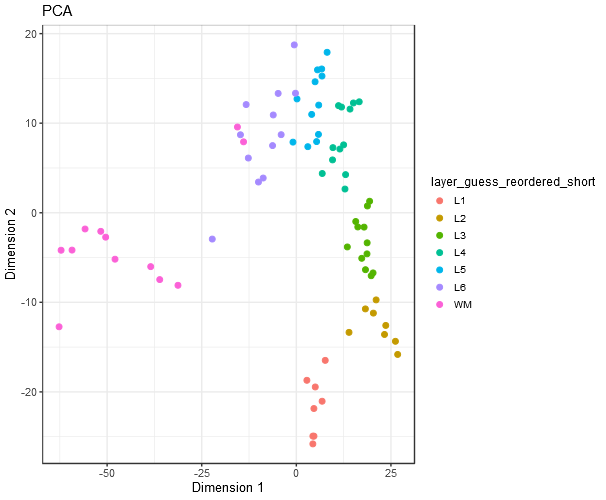

- Explora en con un heatmap la expresión de los genes MOBP, MBP y PCP4. Si hacemos un clustering (agrupamos los genes), ¿cúales genes se parecen más?

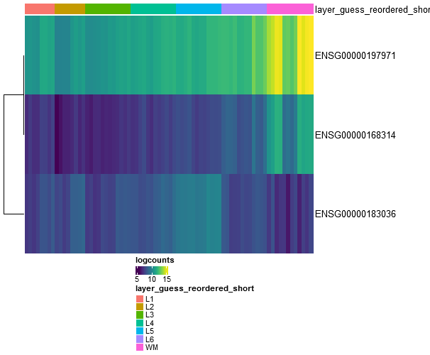

- MOBP y MBP son los más parecidos.
- ¿En qué capas se expresan más los genes MOBP y MBP?
- En WM.

## Proyectos recount

- ReCount: datos de unos 20 estudios.
- recount: 70 mil muestras de RNA-seq uniformemente procesadas.
- recount3: 700 mil muestras de RNA-seq de humano y ratón.

Para recuperar todos los datos de humano en recount3 se puede correr el siguiente código:

```
## Se puede extraer los proyectos con datos de humano en recount3.
human_projects <- available_projects()
```

Para recuperar los datos de un proyecto en específico se puede utilizar el siguiente código:

```
proj_info <- subset(
    human_projects,
    project == "ID del proyecto" & project_type == "data_sources"
)
## Crea un objetio de tipo RangedSummarizedExperiment (RSE)
## con la información a nivel de genes
rse_gene_SRP009615 <- create_rse(proj_info)
```

## Ejercicio

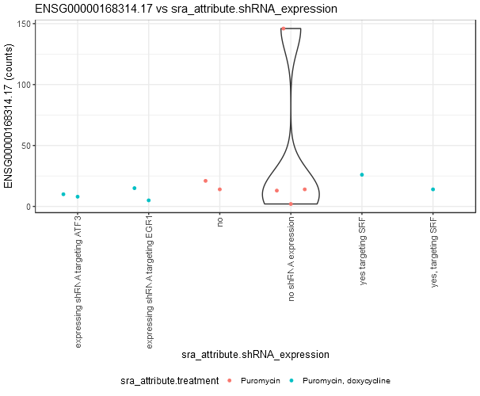